# Murchison Mountains acoustic survey sensitivity analysis

- Show All Code
- Hide All Code
- View Source

Author

Andrew Digby, Glen Greaves

Published

September 29, 2026

**Packages**

```r
library(tidyverse)
packages <- c(
"readxl", "lubridate", "purrr",
"ggplot2", "ggpubr", "scales",
"tictoc",
"yardstick" # for contingency stats
)

suppressMessages(walk(packages, library, character.only = T))

# Utilities:
library(conflicted)
conflicts_prefer(dplyr::select,
                 dplyr::filter,
                 dplyr::lag)

theme_set(theme_minimal(base_size = 16))
theme_update(panel.grid.major = element_blank(), panel.grid.minor = element_blank()) # remove gridlines

# Function for printing tables
render_table <- function(df) {

# Display datatable with numeric columns rounded to 2 digits
  DT::datatable(
    df,
    extensions = 'Buttons',
    options = list(
      dom = 'Bfrtip',
      buttons = c('copy', 'csv', 'excel', 'pdf', 'print'),
      pageLength = 10
    )
  )

}
```

# 1 Parameters

**Parameters**

```r
takahe_sharepoint <- 'https://docnz.sharepoint.com/:x:/t/TakaheRecovery/'

results_file_2024 <- sprintf('/Users/%s/Library/CloudStorage/OneDrive-DepartmentofConservation/Takahe Team/Takahe_Shared_Files/Research/Acoustic survey trials/Murchies Acoustic Survey Trial Data.xlsx', Sys.getenv("USER"))
route_file <- sprintf('/Users/%s/Library/CloudStorage/OneDrive-DepartmentofConservation/Takahe Team/Takahe_Shared_Files/Research/Acoustic survey trials/Acoustic Survey Proposed .xlsx', Sys.getenv("USER"))

n_iter <- 5000
```

# 2 Purpose

Conduct a sensitivity analysis to assess the impact of sampling a subset of territories and listening locations during the acoustic takahe survey in the Murchison Mountains. Use the 2024 acoustic survey results to estimate the subsampling effect.

Have two ways of considering this:

- Number of territories surveyed
- Number of routes surveyed (each route covers multiple territories)

# 3 Method

- For each territory surveyed, have a number of birds detected and number from ground survey (/Users/adigby/Library/CloudStorage/OneDrive-DepartmentofConservation/Takahe Team/Takahe_Shared_Files/Research/Acoustic survey trials/Murchies Acoustic Survey Trial Data.xlsx)
- Select a proportion of the total territories (or routes) sampled, and calculate proportion of birds detected.
- Repeat this 5000 times to get estimate of proportion detected vs proportion of territories/routes sampled
- Calculate the absolute error in the population estimate (compared to ground survey), and also the 95% precision (1 - 95th percentile of absolute error distribution = minimum precision expected for 95% of subsampled surveys at given sampling intensity).
- Follow this process for
  - sampling territories surveyed within each block
  - sampling territories across all blocks
  - sampling routes

Methods summary for a paper:

[output not shown]

# 4 Data

## 4.1 Acoustic survey data

Read 2024 acoustic survey data from /Users/adigby/Library/CloudStorage/OneDrive-DepartmentofConservation/Takahe Team/Takahe_Shared_Files/Research/Acoustic survey trials/Murchies Acoustic Survey Trial Data.xlsx:

**Read data**

```r
# library(Microsoft365R)
#
# # Authenticate with Microsoft 365
# site <- get_sharepoint_site(takahe_sharepoint)
#
# # Access the document library
# doclib <- site$get_drive()
#
# # Download the file
# file <- doclib$get_item("Shared Documents/yourfile.xlsx")
# file$download(dest = "yourfile.xlsx")

# Read the results file and combine all tabs into one dataframe

# Get all sheet names
sheet_names <- excel_sheets(results_file_2024)

# Read and combine all sheets into one data frame
# Convert all columns to character to enable binding different column types
ac2024 <- map_dfr(sheet_names, ~ read_excel(results_file_2024, sheet = .x) %>%
                     mutate(across(everything(), as.character),
                            block = .x)) %>%

  janitor::clean_names(.)

cat(sprintf("Read %d rows from %d sheets in %s\n", nrow(ac2024), length(sheet_names), results_file_2024 ))
```

```
Read 145 rows from 10 sheets in /Users/adigby/Library/CloudStorage/OneDrive-DepartmentofConservation/Takahe Team/Takahe_Shared_Files/Research/Acoustic survey trials/Murchies Acoustic Survey Trial Data.xlsx
```

Tidy data:

- For multiple results from the same territory, take maximum of birds responded.

```r
# Convert to numeric:
ac2024 <- ac2024 %>%
  mutate(across(c(birds_responded, distance_m, birds_surveyed), as.numeric))

# Maximum number of birds recorded in each territory
ac2024_max <- ac2024 %>%
  group_by(territory) %>%
  slice_max(order_by = birds_responded, n = 1, with_ties = FALSE) %>%
  ungroup()
```

## 4.2 Route data

Read proposed route data: this gives which territory is in which route. Read from /Users/adigby/Library/CloudStorage/OneDrive-DepartmentofConservation/Takahe Team/Takahe_Shared_Files/Research/Acoustic survey trials/Acoustic Survey Proposed .xlsx.

```r
routes <- readxl::read_excel(route_file) %>%
  janitor::clean_names()

# Fill down Survey type, name, effort and acoustic points per group
routes <- routes %>%
  group_by(route_group) %>%
  fill(c(survey_type, name, effort_hrs, no_acoustic_points),.direction = 'down')

# Add routes to territory survey results

ac2024_max <- left_join(ac2024_max, routes, by = 'territory', suffix = c('', 'rte'))
```

# 5 Sensitivity by sampling territories

First look at error in population estimate by block, then across all blocks.

## 5.1 Error by block

**Calculate sensitivity by sampling territories**

```r
# Prepare data
acc_dat <- ac2024_max %>%
  mutate(
    birds_responded = as.numeric(birds_responded),
    birds_surveyed = as.numeric(birds_surveyed)
  ) %>%
  filter(
    !is.na(birds_responded),
    !is.na(birds_surveyed),
    birds_surveyed > 0,
    !is.na(block)
  )

props <- seq(0.30, 1.00, by = 0.05)

set.seed(123)

territory_block_sensitivity <- map_dfr(props, function(p) {

  map_dfr(seq_len(n_iter), function(i) {

    sampled <- acc_dat %>%
      group_by(block) %>%
      group_modify(~ {
        slice_sample(
          .x,
          n = max(1, round(nrow(.x) * p))
        )
      }) %>%
      ungroup()

    sampled %>%
      group_by(block) %>%
      summarise(
        territories_sampled = n(),
        accuracy =
          sum(birds_responded) /
          sum(birds_surveyed),
        .groups = "drop"
      ) %>%
      mutate(
        proportion = p,
        iteration = i
      )

  })

})

# Full-survey estimate for each block
block_full_accuracy <- acc_dat %>%
  group_by(block) %>%
  summarise(
    full_accuracy =
      sum(birds_responded) /
      sum(birds_surveyed),
    .groups = "drop"
  )

# Error and precision summaries
territory_block_summary <- territory_block_sensitivity %>%
  left_join(
    block_full_accuracy,
    by = "block"
  ) %>%
  mutate(
    abs_error =
      abs(accuracy - full_accuracy)
  ) %>%
  group_by(block, proportion) %>%
  summarise(
    median_error = median(abs_error),
    mean_error = mean(abs_error),
    p95_error = quantile(abs_error, 0.95),

    error_lower_95 = quantile(abs_error, 0.025),
    error_upper_95 = quantile(abs_error, 0.975),

    precision_median =
      1 - median(abs_error),

    precision_95 =
      1 - quantile(abs_error, 0.95),

    precision_lower =
      1 - quantile(abs_error, 0.975),

    precision_upper =
      1 - quantile(abs_error, 0.025),

    .groups = "drop"
  )
```

Show absolute error from the survey estimate: if sampled 50% of territories, how far from true total will the acoustic estimate be?

**Plot absolute error from sampling territories**

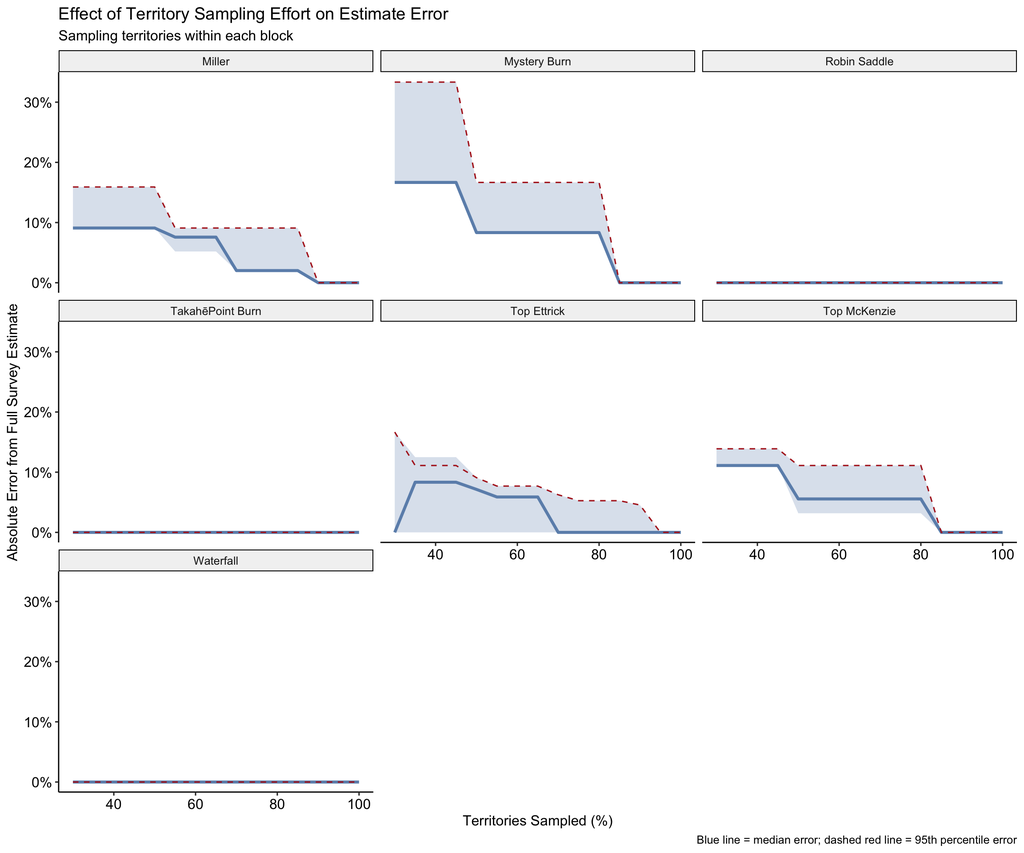

```r
ggplot(
  territory_block_summary,
  aes(
    x = proportion * 100,
    y = median_error
  )) +
  geom_ribbon(
    aes(
      ymin = error_lower_95,
      ymax = error_upper_95
    ),
    fill = "#6C90B9",
    alpha = 0.25
) +
  geom_line(
    linewidth = 1.2,
    colour = "#6C90B9"
  ) +
  geom_line(
    aes(y = p95_error),
    linetype = "dashed",
    colour = "firebrick"
  ) +
  facet_wrap(~block) +
  scale_y_continuous(
    labels = scales::percent
  ) +
  labs(
    title = "Effect of Territory Sampling Effort on Estimate Error",
    subtitle = "Sampling territories within each block",
    x = "Territories Sampled (%)",
    y = "Absolute Error from Full Survey Estimate",
    caption = "Blue line = median error; dashed red line = 95th percentile error"
  ) +
  theme_pubr()
```

## 5.2 Error across all blocks

**Plot sensitivity by sampling territories over all blocks**

```r
# Prepare data
acc_dat <- ac2024_max %>%
  mutate(
    birds_responded = as.numeric(birds_responded),
    birds_surveyed = as.numeric(birds_surveyed)
  ) %>%
  filter(
    !is.na(birds_responded),
    !is.na(birds_surveyed),
    birds_surveyed > 0
  )

# Proportions to test
props <- seq(0.30, 1.00, by = 0.05)


set.seed(123)

territory_sensitivity <- map_dfr(props, function(p) {

  map_dfr(seq_len(n_iter), function(i) {

    sampled <- acc_dat %>%
      slice_sample(
        n = max(1, round(nrow(acc_dat) * p)),
        replace = FALSE
      )

    tibble(
      proportion = p,
      iteration = i,
      territories_sampled = nrow(sampled),
      birds_responded = sum(sampled$birds_responded),
      birds_surveyed = sum(sampled$birds_surveyed),
      accuracy = sum(sampled$birds_responded) /
                 sum(sampled$birds_surveyed)
    )

  })

})

# Calculate error:
territory_full_accuracy <- sum(acc_dat$birds_responded) /
                 sum(acc_dat$birds_surveyed)

territory_summary <- territory_sensitivity %>%
  mutate(
    abs_error = abs(accuracy - territory_full_accuracy)
  ) %>%
  group_by(proportion) %>%
  summarise(
    median_error = median(abs_error),
    mean_error = mean(abs_error),
    p95_error = quantile(abs_error, 0.95),
    lower_95 = quantile(abs_error, 0.025),
    upper_95 = quantile(abs_error, 0.975),
    precision_95 = 1 - quantile(abs_error, 0.95),
    precision_median = 1 - median(abs_error),
    precision_lower = 1 - quantile(abs_error, 0.975),
    precision_upper = 1 - quantile(abs_error, 0.025),
    .groups = "drop"
  )

territory_full_accuracy
```

```
[1] 0.962963
```

**Plot sensitivity by sampling territories over all blocks**

```r
summary(territory_sensitivity$accuracy)
```

```
   Min. 1st Qu.  Median    Mean 3rd Qu.    Max.
 0.8182  0.9524  0.9630  0.9631  0.9737  1.0556
```

**Plot sensitivity by sampling territories over all blocks**

```r
sd(territory_sensitivity$accuracy)
```

```
[1] 0.02364448
```

Plot absolute error:

**Overall absolute error by sampling territories**

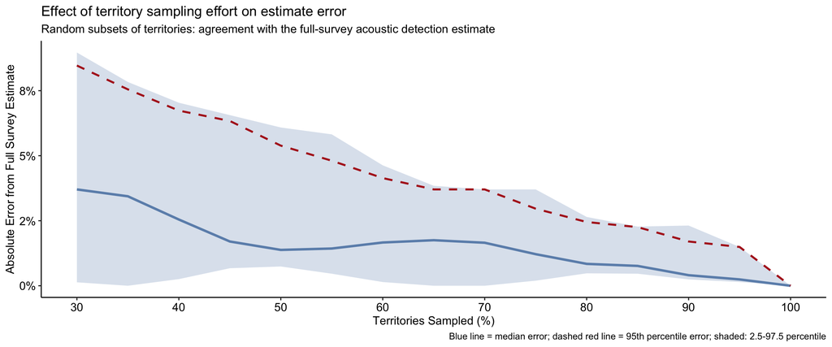

```r
ggplot(territory_summary,
       aes(x = proportion * 100,
           y = median_error)) +
  geom_ribbon(
    aes(
      ymin = lower_95,
      ymax = upper_95
    ),
    fill = "#6C90B9",
    alpha = 0.25
  ) +
  geom_line(
    linewidth = 1.2,
    colour = "#6C90B9"
  ) +
  geom_line(
    aes(y = p95_error),
    linetype = "dashed",
    colour = "firebrick",
    linewidth = 1
  ) +
  scale_x_continuous(
    breaks = seq(30, 100, 10)
  ) +
  scale_y_continuous(
    labels = percent_format(accuracy = 1)
  ) +
  labs(
  title = "Effect of territory sampling effort on estimate error",
  subtitle = "Random subsets of territories: agreement with the full-survey acoustic detection estimate",
  x = "Territories Sampled (%)",
  y = "Absolute Error from Full Survey Estimate",
  caption = "Blue line = median error; dashed red line = 95th percentile error; shaded: 2.5-97.5 percentile"
  ) +
  theme_pubr()
```

Plot precision: when sampling a proportion of the territories, 95% of estimates are at leaset M% as precise as full survey estimate.

**Overall precision by sampling territories**

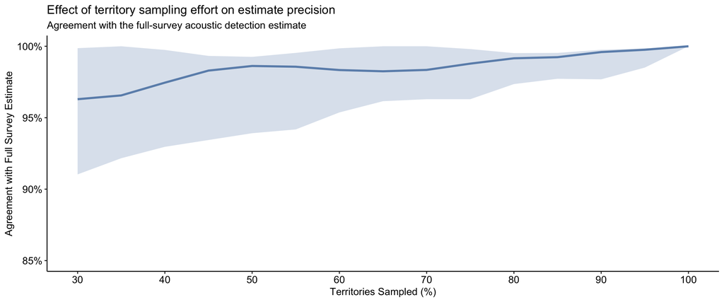

```r
ggplot(
  territory_summary,
  aes(
    x = proportion * 100,
    y = precision_median
  )
) +
  geom_ribbon(
    aes(
      ymin = precision_lower,
      ymax = precision_upper
    ),
    fill = "#6C90B9",
    alpha = 0.25
  ) +
  geom_line(
    colour = "#6C90B9",
    linewidth = 1.2
  ) +
  scale_x_continuous(
    breaks = seq(30, 100, 10)
  ) +
  scale_y_continuous(
    labels = scales::percent_format(accuracy = 1),
    limits = c(0.85, 1)
  ) +
  labs(
  title = "Effect of territory sampling effort on estimate precision",
  subtitle = "Agreement with the full-survey acoustic detection estimate",
  x = "Territories Sampled (%)",
  y = "Agreement with Full Survey Estimate"
  ) +
  theme_pubr()
```

# 6 Sensitivity by sampling route

1. Identify all unique route_groups.
2. Sample a proportion of those routes.
3. Keep all territories belonging to the chosen routes.
4. Calculate the overall accuracy.
5. Compare that estimate to the full dataset accuracy.

**Plot sensitivity by sampling outes**

```r
# Prepare data
acc_dat <- ac2024_max %>%
  mutate(
    birds_responded = as.numeric(birds_responded),
    birds_surveyed = as.numeric(birds_surveyed)
  ) %>%
  filter(
    !is.na(birds_responded),
    !is.na(birds_surveyed),
    birds_surveyed > 0,
    !is.na(route_group)
  )

props <- seq(0.30, 1.00, by = 0.05)
set.seed(123)

# Full-survey estimate
route_full_accuracy <-
  sum(acc_dat$birds_responded) /
  sum(acc_dat$birds_surveyed)

# Route-level sensitivity analysis
route_sensitivity <- map_dfr(props, function(p) {

  map_dfr(seq_len(n_iter), function(i) {

    sampled_routes <- acc_dat %>%
      distinct(route_group) %>%
      slice_sample(
        n = max(
          1,
          round(n_distinct(acc_dat$route_group) * p)
        )
      )

    sampled_dat <- acc_dat %>%
      semi_join(
        sampled_routes,
        by = "route_group"
      )

    tibble(
      proportion = p,
      iteration = i,
      routes_sampled = n_distinct(sampled_dat$route_group),
      territories_sampled = nrow(sampled_dat),
      birds_responded = sum(sampled_dat$birds_responded),
      birds_surveyed = sum(sampled_dat$birds_surveyed),
      accuracy =
        sum(sampled_dat$birds_responded) /
        sum(sampled_dat$birds_surveyed)
    )

  })

})

# Error summaries
route_summary <- route_sensitivity %>%
  mutate(
    abs_error = abs(accuracy - route_full_accuracy)
  ) %>%
  group_by(proportion) %>%
  summarise(
    median_error = median(abs_error),
    mean_error = mean(abs_error),
    p95_error = quantile(abs_error, 0.95),

    lower_95 = quantile(abs_error, 0.025),
    upper_95 = quantile(abs_error, 0.975),

    precision_median = 1 - median(abs_error),
    precision_95 = 1 - quantile(abs_error, 0.95),

    precision_lower = 1 - quantile(abs_error, 0.975),
    precision_upper = 1 - quantile(abs_error, 0.025),

    .groups = "drop"
  )
```

Error plot:

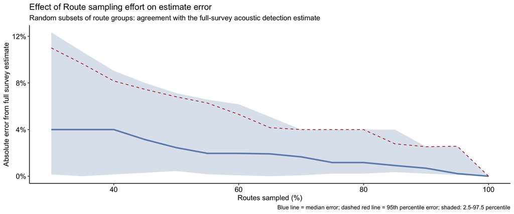

```r
ggplot(
  route_summary,
  aes(
    x = proportion * 100,
    y = median_error
  )
) +
  geom_ribbon(
    aes(
      ymin = lower_95,
      ymax = upper_95
    ),
    fill = "#6C90B9",
    alpha = 0.25
  ) +
  geom_line(
    linewidth = 1.2,
    colour = "#6C90B9"
  ) +
  geom_line(
    aes(y = p95_error),
    linetype = "dashed",
    colour = "firebrick"
  ) +
  scale_y_continuous(
    labels = scales::percent
  ) +
  labs(
    title = "Effect of Route sampling effort on estimate error",
    subtitle = "Random subsets of route groups: agreement with the full-survey acoustic detection estimate",
    x = "Routes sampled (%)",
    y = "Absolute error from full survey estimate",
      caption = "Blue line = median error; dashed red line = 95th percentile error; shaded: 2.5-97.5 percentile"
  ) +
  theme_pubr()
```

Precision plot:

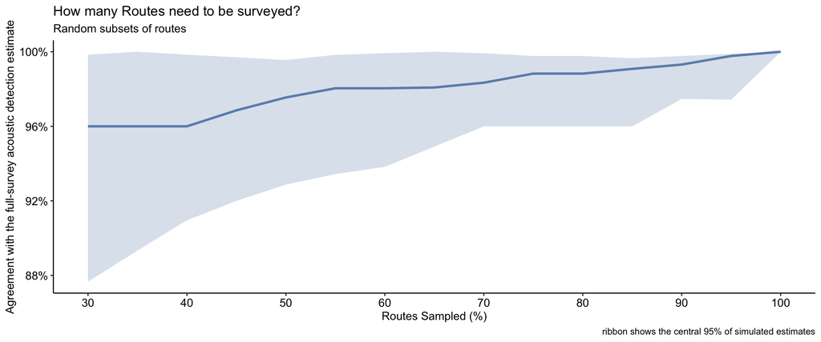

```r
ggplot(
  route_summary,
  aes(
    x = proportion * 100,
    y = precision_median
  )
) +
  geom_ribbon(
    aes(
      ymin = precision_lower,
      ymax = precision_upper
    ),
    fill = "#6C90B9",
    alpha = 0.25
  ) +
  geom_line(
    colour = "#6C90B9",
    linewidth = 1.2
  ) +
  scale_x_continuous(
    breaks = seq(30, 100, 10)
  ) +
  scale_y_continuous(
    labels = scales::percent_format(accuracy = 1)
  ) +
  labs(
    title = "How many Routes need to be surveyed?",
    subtitle = "Random subsets of routes",
    x = "Routes Sampled (%)",
    y = "Agreement with the full-survey acoustic detection estimate",
    caption = " ribbon shows the central 95% of simulated estimates"
  ) +
  theme_pubr()
```